# **Adhesión a principios democráticos liberales: entre las percepciones individuales y los contextos nacionales**

**Martina Gallardo, Cristóbal Unda y Diego Vicuña**

**Análisis de datos multinivel - 2025**

**Departamento de Sociología, Universidad de Chile**

Santiago, 26 de Junio de 2025

Github repo

# Introducción

- Durante la última década, la democracia liberal ha enfrentado múltiples tensiones. Aunque se mantienen formalmente prácticas como elecciones libres o división de poderes, ha crecido la insatisfacción ciudadana con su funcionamiento (Wike, Silver & Castillo, 2019). Esta paradoja genera una pregunta clave: ¿realmente la ciudadanía sigue adhiriendo a los principios democráticos liberales?
- **Variable dependiente:**

  > Índice de Adhesión a Principios Democráticos Liberales (0-30)
- **Variables asociadas Nivel 1:**

  > Género (mujer), Autopercepción de grupo económico e Importancia de vivir en democracia
- **Variables asociadas Nivel 2:**

# Antecedentes

- Inglehart y Welzel (2005a; 2005b) argumentan que los valores de autoexpresión y autonomía, fortalecidos por el bienestar material y la libertad cultural, son clave para sostener la democracia. Estos valores, además, se ven reforzados por climas democráticos nacionales, articulando una relación entre contexto estructural y disposiciones individuales.
- Alexander y Welzel (2011) encontraron que las mujeres suelen mostrar mayor apoyo a la equidad y los derechos civiles. No obstante, su influencia concreta sobre el respaldo a la democracia liberal todavía es debatida.

¿Cómo inciden las percepciones individuales y los climas democráticos nacionales en el respaldo ciudadano a los principios de la democracia liberal?

# Hipótesis:

## Nivel 1:

$H_1a$: Las mujeres presentan un mayor respaldo a los principios de la democracia liberal que los hombres.

## Nivel 2

$H_2a$: Los países en los que la ciudadanía percibe que viven en una democracia presentan un mayor respaldo promedio a los principios de la democracia liberal.

$H_2b$: Los países donde las personas valoran más vivir en democracia presentan un mayor respaldo promedio a los principios de la democracia liberal.

**Interacción entre niveles**

$H3a$: El efecto positivo del género (a favor de las mujeres) sobre el respaldo a los principios de la democracia liberal es más intenso a medida que el país sea percibido más democrático.

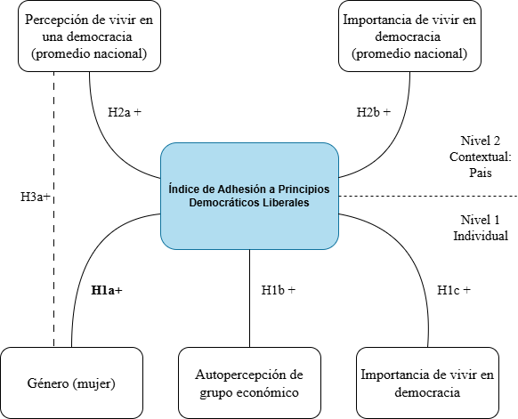

Modelo teórico (hipótesis)

# Metodología

## Datos

Se utilizó la base de datos de la **séptima ola del World Values Survey (2017–2022)**, compuesta por **88.207 casos** en **66 países**. La estructura jerárquica de la base (individuos anidados en países) permite el uso de modelos multinivel. Se eliminaron casos con datos faltantes y se construyó un índice compuesto que captura percepciones sobre tres principios fundamentales de la democracia liberal: soberanía popular, protección de derechos civiles e igualdad de género.

## Variables

##### Estadísticos descriptivos univariados nivel 1

Table 1: Variables nivel 1

|  | var | label | n | NA.prc | mean | sd | range |
| --- | --- | --- | --- | --- | --- | --- | --- |
| 3 | indice_dem | indice_dem | 88207 | 0 | 23.36 | 6.34 | 30 (0-30) |
| 5 | país | ISO 3166-1 numeric country code | 88207 | 0 | 443.67 | 255.20 | 889 (20-909) |
| 1 | grp_econ | Scale of incomes | 88207 | 0 | 4.95 | 2.08 | 9 (1-10) |
| 2 | imp_dem | Importance of democracy | 88207 | 0 | 8.38 | 2.11 | 9 (1-10) |
| 4 | mujer | mujer | 88207 | 0 | 0.52 | 0.50 | 1 (0-1) |

##### Estadisticos descriptivos univariados nivel 2

Table 2: Variables nivel 2

| var | label | n | NA.prc | mean | sd | range |
| --- | --- | --- | --- | --- | --- | --- |
| cuan_dem | cuan_dem | 66 | 0 | 6.08 | 1.05 | 4.25 (3.73-7.98) |
| prom_imp_dem | prom_imp_dem | 66 | 0 | 8.39 | 0.60 | 2.61 (6.94-9.55) |

## Métodos

Se estimaron modelos multinivel con interceptos aleatorios y, posteriormente, con pendientes aleatorias para evaluar efectos contextuales. Se reporta el ICC, los coeficientes de regresión, errores estándar y varianzas explicadas. El análisis se realizó con software estadístico compatible con modelamiento multinivel, siguiendo recomendaciones metodológicas de Goldstein (1995) y Finch et al. (2014).

Se estimaron un total de 5 modelos.

## Modelo de nivel 2: incluye predictores contextuales.

$$\text{Y}_{ij} \;=\; \gamma_{00}
+ \gamma_{01}\,(\text{cuan_dem}_{j})
+ \gamma_{02}\,(\text{prom_imp_dem}_{j})
+ u_{0\text{j}}
+ e_{ij}$$

## Modelo 3 combinado:

$$\text{Y}_{ij} \;=\; \gamma_{00}
+ \gamma_{10}\,(\text{grp_econ}_{ij})
+ \gamma_{20}\,(\text{mujer}_{ij})
+ \gamma_{30}\,(\text{imp_dem}_{ij})
+ \gamma_{01}\,(\text{cuan_dem}_{j})
+ \gamma_{02}\,(\text{prom_imp_dem}_{j})
+ u_{0\text{j}}
+ e_{ij}$$

## Modelo 4 con pendiente aleatoria:

$$\text{Y}_{ij} \;=\; \gamma_{00}
+ \gamma_{10}\,(\text{grp_econ}_{ij})
+ \gamma_{20}\,(\text{mujer}_{ij})
+ \gamma_{30}\,(\text{imp_dem}_{ij})
+ \gamma_{01}\,(\text{cuan_dem}_{j})
+ \gamma_{02}\,(\text{prom_imp_dem}_{j})
+ u_{0\text{j}}
+ u_{\text{1j}}(\text{imp_dem}_{ij})
+ e_{ij}$$

## Modelo 5 de interacción:

$$\text{Y}_{ij} \;=\; \gamma_{00}
+ \gamma_{10}\,(\text{grp_econ}_{ij})
+ \gamma_{20}\,(\text{mujer}_{ij})
+ \gamma_{30}\,(\text{imp_dem}_{ij})
+ \gamma_{01}\,(\text{cuan_dem}_{j})
+ \gamma_{02}\,(\text{prom_imp_dem}_{j})
+ \gamma_{21}\,(\text{mujer}_{ij}⋅\text{cuan_dem}_{j})
+ u_{0\text{j}}
+ u_{\text{1j}}(\text{mujer}_{ij})
+ e$$

# Resultados

## Gráfico 1

### Relación de promedio de percepción sobre cuan democratico es un país con Índice de Adhesión a Principios Democráticos Liberalesl

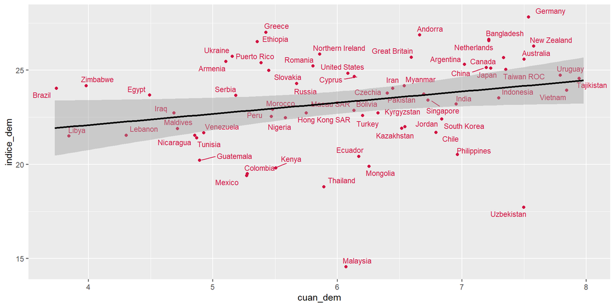

## Gráfico 2

### Relación de promedio de importancia de vivir en un país democratico con Índice de Adhesión a Principios Democráticos Liberales

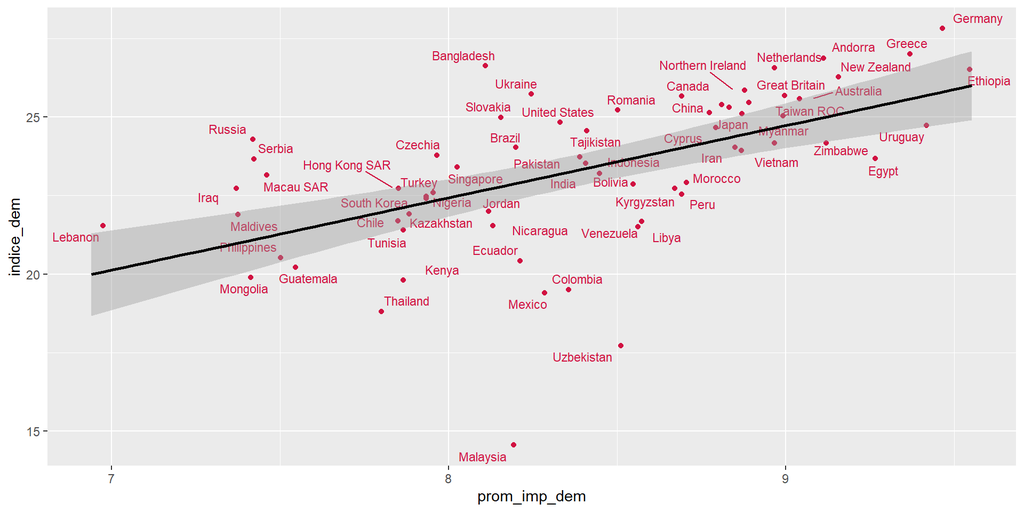

## Modelos centrados e interacción

|  | Nulo |  |  | Var. Niv. 1 (centrado) |  |  | Var. Niv. 2 (centrado) |  |  | Combinado (centrado) |  |  | Pendiente Aleatoria (centrado) |  |  | Interacción entre niveles |  |  |
| --- | --- | --- | --- | --- | --- | --- | --- | --- | --- | --- | --- | --- | --- | --- | --- | --- | --- | --- |
| Predictors | Estimates | std. Error | p | Estimates | std. Error | p | Estimates | std. Error | p | Estimates | std. Error | p | Estimates | std. Error | p | Estimates | std. Error | p |
| (Intercept) | 23.32 | 0.30 | **<0.001** | 23.39 | 0.30 | **<0.001** | 23.34 | 0.25 | **<0.001** | 23.40 | 0.25 | **<0.001** | 23.37 | 0.25 | **<0.001** | 23.39 | 0.25 | **<0.001** |
| grp econ cmc |  |  |  | -0.01 | 0.01 | 0.372 |  |  |  | -0.01 | 0.01 | 0.372 | -0.02 | 0.01 | **0.026** | -0.01 | 0.01 | 0.327 |
| mujer |  |  |  | -0.13 | 0.04 | **<0.001** |  |  |  | -0.13 | 0.04 | **<0.001** | -0.11 | 0.04 | **0.002** | -0.11 | 0.07 | 0.141 |
| imp dem cmc |  |  |  | 1.08 | 0.01 | **<0.001** |  |  |  | 1.08 | 0.01 | **<0.001** | 1.08 | 0.06 | **<0.001** | 1.08 | 0.01 | **<0.001** |
| cuan dem gmc |  |  |  |  |  |  | 0.22 | 0.25 | 0.382 | 0.22 | 0.25 | 0.381 | 0.01 | 0.23 | 0.976 | 0.27 | 0.25 | 0.284 |
| prom imp dem gmc |  |  |  |  |  |  | 2.19 | 0.44 | **<0.001** | 2.19 | 0.44 | **<0.001** | 2.36 | 0.40 | **<0.001** | 2.19 | 0.43 | **<0.001** |
| mujer × cuan dem gmc |  |  |  |  |  |  |  |  |  |  |  |  |  |  |  | -0.08 | 0.07 | 0.225 |
| Random Effects |  |  |  |  |  |  |  |  |  |  |  |  |  |  |  |  |  |  |
| σ<sup>2</sup> | 34.40 |  |  | 29.58 |  |  | 34.40 |  |  | 29.58 |  |  | 28.72 |  |  | 29.51 |  |  |
| τ<sub>00</sub> | 6.02 <sub>país</sub> |  |  | 6.03 <sub>país</sub> |  |  | 4.18 <sub>país</sub> |  |  | 4.19 <sub>país</sub> |  |  | 4.04 <sub>país</sub> |  |  | 4.03 <sub>país</sub> |  |  |
| τ<sub>11</sub> |  |  |  |  |  |  |  |  |  |  |  |  | 0.20 <sub>país.imp_dem_cmc</sub> |  |  | 0.24 <sub>país.mujer</sub> |  |  |
| ρ<sub>01</sub> |  |  |  |  |  |  |  |  |  |  |  |  | 0.41 <sub>país</sub> |  |  | -0.10 <sub>país</sub> |  |  |
| ICC | 0.15 |  |  | 0.17 |  |  | 0.11 |  |  | 0.12 |  |  | 0.15 |  |  | 0.12 |  |  |
| N | 66 <sub>país</sub> |  |  | 66 <sub>país</sub> |  |  | 66 <sub>país</sub> |  |  | 66 <sub>país</sub> |  |  | 66 <sub>país</sub> |  |  | 66 <sub>país</sub> |  |  |
| Observations | 88207 |  |  | 88207 |  |  | 88207 |  |  | 88207 |  |  | 88207 |  |  | 88207 |  |  |
| Marginal R<sup>2</sup> / Conditional R<sup>2</sup> | 0.000 / 0.149 |  |  | 0.119 / 0.268 |  |  | 0.044 / 0.148 |  |  | 0.163 / 0.267 |  |  | 0.165 / 0.286 |  |  | 0.164 / 0.265 |  |  |

## Tablas de Devianza

Tabla de devianza 1: Comparación Pendiente Fija con P.A. Imp_dem

|  | npar | AIC | BIC | logLik | -2*log(L) | Chisq | Df | Pr(>Chisq) |
| --- | --- | --- | --- | --- | --- | --- | --- | --- |
| Combinado (centrado) | 8 | 549423.9 | 549499.0 | -274704.0 | 549407.9 | NA | NA | NA |
| P.A. Imp_dem | 10 | 547083.7 | 547177.6 | -273531.9 | 547063.7 | 2344.214 | 2 | 0 |

Tabla de devianza 2: Comparación Pendiente Fija con P.A. Mujer

|  | npar | AIC | BIC | logLik | -2*log(L) | Chisq | Df | Pr(>Chisq) |
| --- | --- | --- | --- | --- | --- | --- | --- | --- |
| Combinado (centrado) | 8 | 549423.9 | 549499.0 | -274704.0 | 549407.9 | NA | NA | NA |
| P.A. Mujer | 11 | 549324.7 | 549427.9 | -274651.3 | 549302.7 | 105.2886 | 3 | 0 |

## Gráfico de pendientes aleatorias

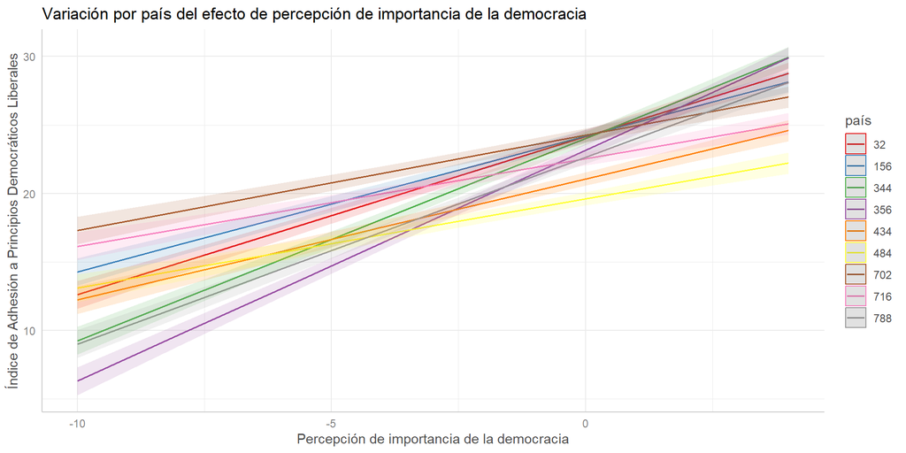

## Interacción entre niveles

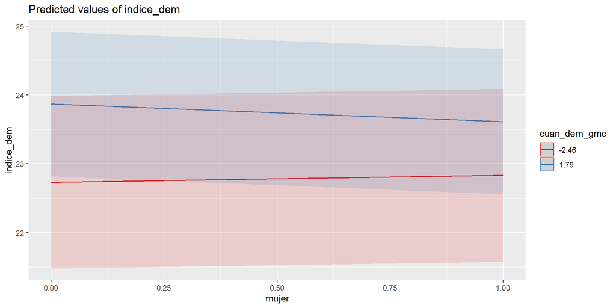

## Casos influyentes

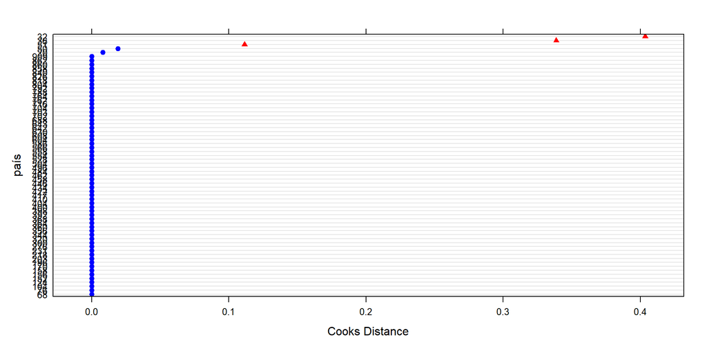

## Modelo teórico con resultados

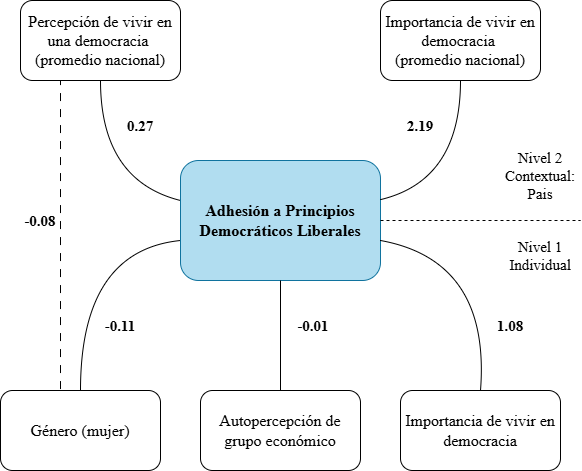

# Conclusiones

## Se rechaza:

Nivel 1:

Nivel 2:

1. H0-2b → La valoración promedio de vivir en democracia no se asocia con un mayor respaldo a los principios de la democracia liberal.

## Se acepta:

Nivel 1:

Nivel 2:

1. $H_2b$: Los países donde las personas valoran más vivir en democracia presentan un mayor respaldo promedio a los principios de la democracia liberal.

## Limitaciones:

1. El cuestionario se basa en percepciones, lo que puede generar tautologías.
2. Orden temporal entre variables es debatible (imp_dem → índice_dem).

## Referencias

Alexander, A. C., & Welzel, C. (2011). Empowering women: The role of emancipative beliefs. European Sociological Review, 27(3), 364–384. https://doi.org/10.1093/esr/jcq012

Almond, G. A., & Verba, S. (1963). The Civic Culture: Political Attitudes and Democracy in Five Nations. Princeton University Press.

Ariely, G., & Davidov, E. (2011). Can we rate public support for democracy in a comparable way? Social Indicators Research, 104(2), 271–286. https://doi.org/10.1007/s11205-010-9693-5

Bellino, M. J. (2017). Democracia liberal y democracia participativa: una tensión no resuelta. Revista LyE, (25), 1–20. http://revistas.derecho.uba.ar/index.php/revistalye/article/view/1037

Castro Domingo, P. (2011). Cultura política: una propuesta socio-antropológica de la construcción de sentido en la política. Región y Sociedad, 23(50), 215–247. http://www.redalyc.org/articulo.oa?id=10218443009

Córdoba Gómez, M. (2008). Democracia liberal y democracia participativa: una tensión no resuelta. Andamios, 5(10), 9–32. https://www.scielo.org.mx/scielo.php?script=sci_arttext&pid=S1870-0063200800030000

Finch, W. H., Bolin, J. E., & Kelley, K. (2014). Multilevel modeling using R. CRC Press. https://doi.org/10.1201/b16042

Franetovic, G., & Castillo, J.-C. (2022). Preferences for income redistribution in unequal contexts: Changes in Latin America between 2008 and 2018. Frontiers in Sociology, 7, 806458. https://doi.org/10.3389/fsoc.2022.806458

Goldstein, H. (1995). Multilevel statistical models (2nd ed.). Edward Arnold.

Inglehart, R., & Welzel, C. (2005a). Modernization, cultural change, and democracy: The human development sequence. Cambridge University Press.

Inglehart, R., & Welzel, C. (2005b). Liberalism, postmaterialism, and the growth of freedom. International Review of Sociology, 15(1), 81–108. https://doi.org/10.1080/03906700500038579

Kong, M. (2024). Individual Perspectives on Liberal Democracy: Insights from World Values Survey. International Journal of High School Research, 6(4), 45–60. https://doi.org/10.36838/v6i4.5

Lee, S. K. (2024). Inequality and the Eroding Base of Liberal Democracy. Social Science Research, 113, 103087. https://doi.org/10.1016/j.ssresearch.2024.103087

Offe, C. (2011). Crisis and innovation of liberal democracy: Can deliberation be institutionalised? Czech Sociological Review, 47(3), 447–472. Our World in Data. (2024). Liberal Democracy Index – V-Dem Central Estimate, Population-Weighted. OurWorldInData.org. https://ourworldindata.org/grapher/liberal-democracy-index

Serret, E. (2004). Género y democracia. Revista Venezolana de Estudios de la Mujer, 9(21), 35–47. https://www.redalyc.org/pdf/315/31502103.pdf

Wike, R., Silver, L., & Castillo, A. (2019). Many across the globe are dissatisfied with how democracy is working. Pew Research Center. https://www.pewresearch.org/global/2019/04/29/many-across-the-globe-are-dissatisfied-with-how-democracy-is-working/